# ANIGN

Matthew Zebert

November 16, 2017

Step 1: Collect stock data of market segment segment

```r
library(quantmod)
```

```r
#Small Cap
# #Example Pulls
# getSymbols(c("GOOGL","MSFT","AMZN", "FB", "BKS", "MOSY"))
#
# chartSeries(GOOGL, subset='last 3 months'); addBBands()
#
#Large Cap Tech data pull

getSymbols("AAPL",from = as.Date("2017-04-01"), to = as.Date("2017-11-01"))
```

[output not shown]

[output not shown]

```
## [1] "AAPL"
```

```r
AAPL <-  data.frame(date=index(AAPL), coredata(AAPL))
colnames(AAPL) <- c("date","open","high", "low", "close", "volume", "adjusted")

getSymbols("GOOGL",from = as.Date("2017-04-01"), to = as.Date("2017-11-01"))
```

```
## [1] "GOOGL"
```

```r
#creating date column
GOOGL <-  data.frame(date=index(GOOGL), coredata(GOOGL))
#rename for stacking later
colnames(GOOGL) <- c("date","open","high", "low", "close", "volume", "adjusted")


getSymbols("MSFT",from = as.Date("2017-04-01"), to = as.Date("2017-11-01"))
```

```
## [1] "MSFT"
```

```r
MSFT <-  data.frame(date=index(MSFT), coredata(MSFT))
colnames(MSFT) <- c("date","open","high", "low", "close", "volume", "adjusted")

getSymbols("AMZN",from = as.Date("2017-04-01"), to = as.Date("2017-11-01"))
```

```
## [1] "AMZN"
```

```r
AMZN <-  data.frame(date=index(AMZN), coredata(AMZN))
colnames(AMZN) <- c("date","open","high", "low", "close", "volume", "adjusted")

getSymbols("FB",from = as.Date("2017-04-01"), to = as.Date("2017-11-01"))
```

```
## [1] "FB"
```

```r
FB <-  data.frame(date=index(FB), coredata(FB))
colnames(FB) <- c("date","open","high", "low", "close", "volume", "adjusted")

# reference -> getSymbols("^GSPC", env = sp500, src = "yahoo", from = as.Date("1960-01-04"), to = as.Date("2009-01-01"))
```

Step 2: Collect daily counts of google search of ticker for each stock

```r
# install.packages("searchConsoleR")
# install.packages("googleAuthR")

library(gtrendsR) # looks like 250 obervations is the max (04 - 12)
AAPL_G <-gtrends("AAPL", time = "2017-04-01 2017-12-01")$interest_over_time


GOOGL_G <-gtrends("GOOGL", time = "2017-04-01 2017-12-01")$interest_over_time
MSFT_G <-gtrends("MSFT", time = "2017-04-01 2017-12-01")$interest_over_time
AMZN_G <-gtrends("AMZN", time = "2017-04-01 2017-12-01")$interest_over_time
FB_G <-gtrends("FB", time = "2017-04-01 2017-12-01")$interest_over_time


#query across all stock tickers at once
```

Step2.5: Merge Data frames:

```r
AAPL$date <- as.Date (AAPL$date, format= "%y/%m/%d")
AAPL_G$date <- as.Date (AAPL_G$date, format= "%y/%m/%d")
AAPLm <-  merge(AAPL, AAPL_G, by="date", all.x=TRUE)
AAPLm$hits.c <- AAPLm$hits - mean(AAPLm$hits)
AAPLm$volume.c <- AAPLm$volume - mean(AAPLm$volume)

GOOGL$date <- as.Date (GOOGL$date, format= "%y/%m/%d")
GOOGL_G$date <- as.Date (GOOGL_G$date, format= "%y/%m/%d")
GOOGLm <-  merge(GOOGL, GOOGL_G, by="date", all.x=TRUE)
GOOGLm$hits.c <- GOOGLm$hits - mean(GOOGLm$hits)
GOOGLm$volume.c <- GOOGLm$volume - mean(GOOGLm$volume)

MSFT$date <- as.Date (MSFT$date, format= "%y/%m/%d")
MSFT_G$date <- as.Date (MSFT_G$date, format= "%y/%m/%d")
MSFTm <-  merge(MSFT, MSFT_G, by="date", all.x=TRUE)
MSFTm$hits.c <- MSFTm$hits - mean(MSFTm$hits)
MSFTm$volume.c <- MSFTm$volume - mean(MSFTm$volume)


AMZN$date <- as.Date (AMZN$date, format= "%y/%m/%d")
AMZN_G$date <- as.Date (AMZN_G$date, format= "%y/%m/%d")
AMZNm <-  merge(AMZN, AMZN_G, by="date", all.x=TRUE)
AMZNm$hits.c <- AMZNm$hits - mean(AMZNm$hits)
AMZNm$volume.c <- AMZNm$volume - mean(AMZNm$volume)

FB$date <- as.Date (FB$date, format= "%y/%m/%d")
FB_G$date <- as.Date (FB_G$date, format= "%y/%m/%d")
FBm <-  merge(FB, FB_G, by="date", all.x=TRUE)
FBm$hits.c <- FBm$hits - mean(FBm$hits)
FBm$volume.c <- FBm$volume - mean(FBm$volume)
```

Step 3:EDA - plotting a scaled version of the google trend hits on top of the stock price chart

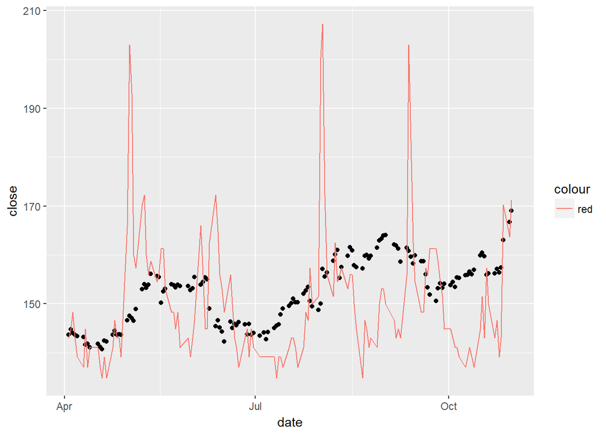

```r
#EDA of Google Trends
# summary(AAPL_G)
# hist(AAPL_G$hits)
# plot(AAPL_G$date, AAPL_G$hits)
#
# #EDA of Price
# plot(AAPL$date,AAPL$AAPL.Close)



#hits overlayed on price



p <- ggplot(AAPLm, aes(x = date))
  p <- p + geom_point(aes(y = close))
    # adding the hits data, transformed to match roughly the range of the price
  p <- p + geom_line(aes(y = log(hits)*45, color = "red"))
  #p <- p + scale_y_continuous(sec.axis = sec_axis(~.*.5,name = "Google Hits"))
p
```

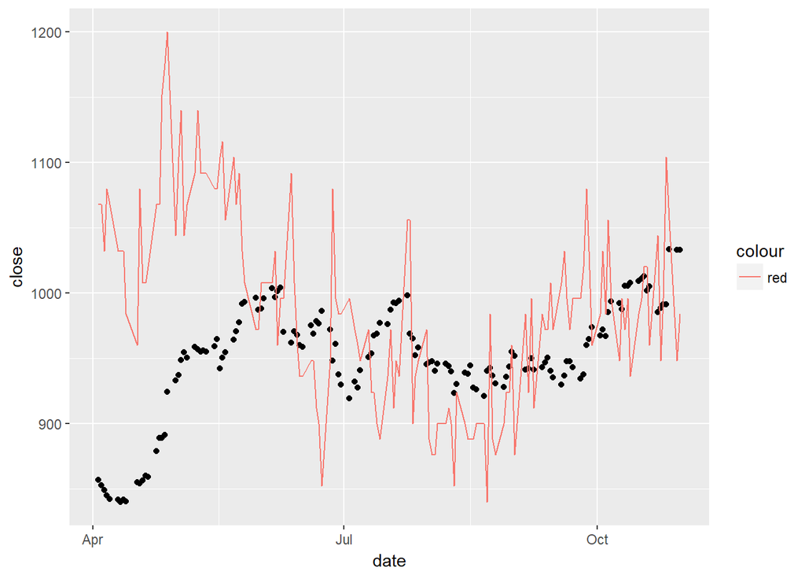

```r
p <- ggplot(GOOGLm, aes(x = date))
  p <- p + geom_point(aes(y = close))
    # adding the hits data, transformed to match roughly the range of the price
  p <- p + geom_line(aes(y = hits*12, color = "red"))
  #p <- p + scale_y_continuous(sec.axis = sec_axis(~.*.5,name = "Google Hits"))
p
```

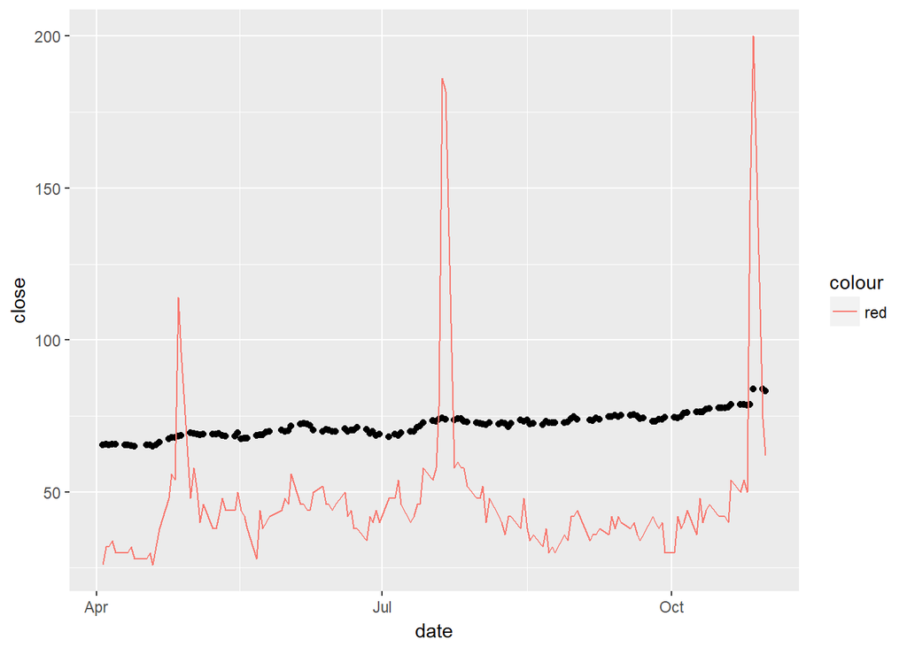

```r
p <- ggplot(MSFTm, aes(x = date))
  p <- p + geom_point(aes(y = close))
    # adding the hits data, transformed to match roughly the range of the price
  p <- p + geom_line(aes(y = hits*2, color = "red"))
  #p <- p + scale_y_continuous(sec.axis = sec_axis(~.*.5,name = "Google Hits"))
p
```

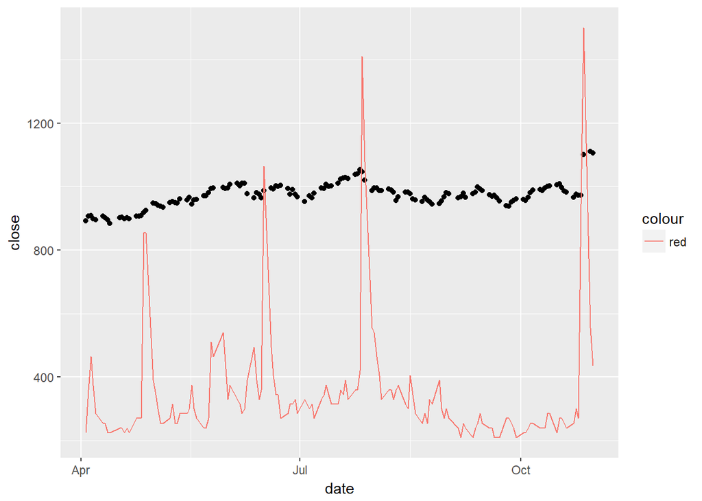

```r
p <- ggplot(AMZNm, aes(x = date))
  p <- p + geom_point(aes(y = close))
    # adding the hits data, transformed to match roughly the range of the price
  p <- p + geom_line(aes(y = hits*15, color = "red"))
  #p <- p + scale_y_continuous(sec.axis = sec_axis(~.*.5,name = "Google Hits"))
p
```

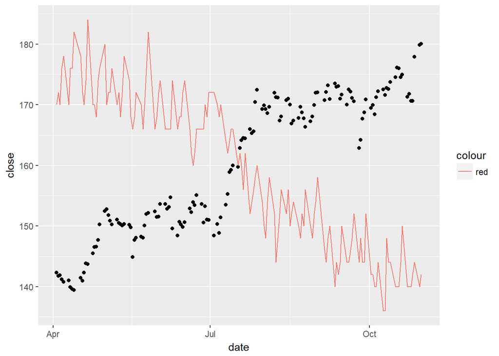

```r
p <- ggplot(FBm, aes(x = date))
  p <- p + geom_point(aes(y = close))
    # adding the hits data, transformed to match roughly the range of the price
  p <- p + geom_line(aes(y = hits*2, color = "red"))
  #p <- p + scale_y_continuous(sec.axis = sec_axis(~.*.5,name = "Google Hits"))
p
```

Most of these plots have a difficulty of showing the hits accurately. This is due to the process google uses. Instead of giving their actual counts of the searched text. They give a distribution between 0 and 100 of how popular the searched text is, compared to the other days in the range of time you specify. I then scaled each “hits” varliable by any number that would make the hits overlay close to the stock price (and therefore didnt include a second axis of y values because they are meaningless in this plot)

Step 4: Create models End all goal y ~ sentiment + date + volume + (1|Company) + (1|year)

```r
#Combine into one data set
library(arm)
library(gdata)
m1 <- lm(close ~ date + hits + log(volume), data = GOOGLm)
display(m1)
```

```
## lm(formula = close ~ date + hits + log(volume), data = GOOGLm)
##             coef.est coef.se
## (Intercept) -6294.68   915.64
## date            0.40     0.05
## hits            0.22     0.54
## log(volume)    24.46     8.76
## ---
## n = 148, k = 4
## residual sd = 35.05, R-Squared = 0.35
```

```r
#large_cap <- rbind(GOOGLm, AMZNm, FBm)
large_cap <- combine(AAPLm, GOOGLm, MSFTm, AMZNm, FBm)
m2 <- lmer(close ~ date + hits + log(volume)+ (1|source), data = large_cap)
display(m2)
```

```
## lmer(formula = close ~ date + hits + log(volume) + (1 | source),
##     data = large_cap)
##             coef.est coef.se
## (Intercept) -3358.23   325.57
## date            0.21     0.01
## hits            0.20     0.10
## log(volume)     8.02     2.96
##
## Error terms:
##  Groups   Name        Std.Dev.
##  source   (Intercept) 466.44
##  Residual              23.28
## ---
## number of obs: 740, groups: source, 5
## AIC = 6814.5, DIC = 6815.6
## deviance = 6809.0
```

```r
summary(m2)
```

```
## Linear mixed model fit by REML ['lmerMod']
## Formula: close ~ date + hits + log(volume) + (1 | source)
##    Data: large_cap
##
## REML criterion at convergence: 6802.5
##
## Scaled residuals:
##     Min      1Q  Median      3Q     Max
## -3.7322 -0.3890 -0.0099  0.4203  4.6621
##
## Random effects:
##  Groups   Name        Variance Std.Dev.
##  source   (Intercept) 217567.1 466.44
##  Residual                541.8  23.28
## Number of obs: 740, groups:  source, 5
##
## Fixed effects:
##               Estimate Std. Error t value
## (Intercept) -3.358e+03  3.256e+02 -10.315
## date         2.121e-01  1.404e-02  15.106
## hits         1.987e-01  9.592e-02   2.071
## log(volume)  8.021e+00  2.960e+00   2.709
##
## Correlation of Fixed Effects:
##             (Intr) date   hits
## date        -0.755
## hits        -0.006  0.090
## log(volume) -0.165  0.036 -0.522
```

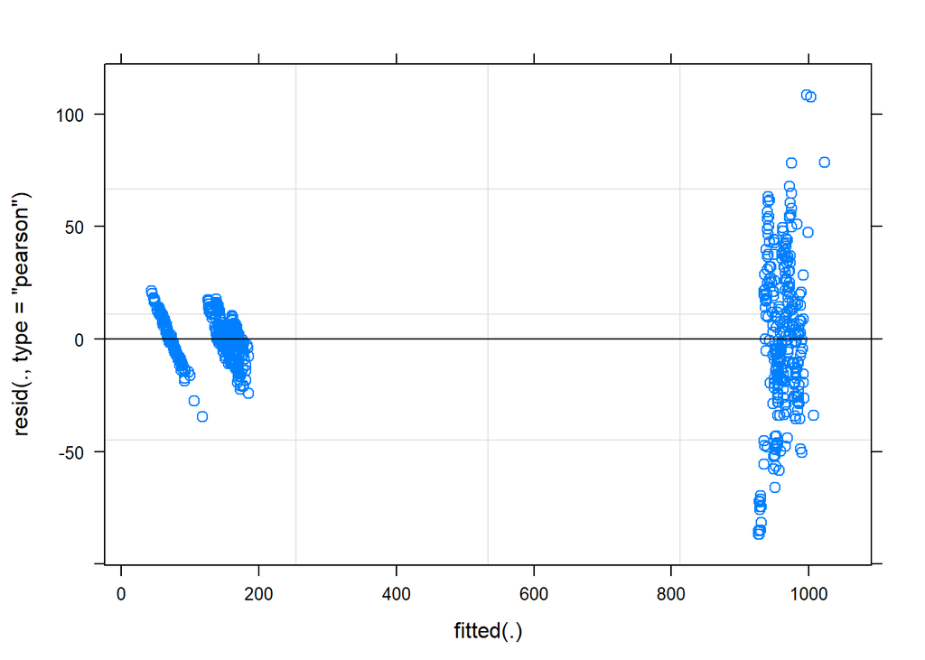

```r
# Reference for similiar example:
#                Lab: Logistic Regression, LDA, QDA, and KNN . . . . . . 4.6




plot(m2)
```

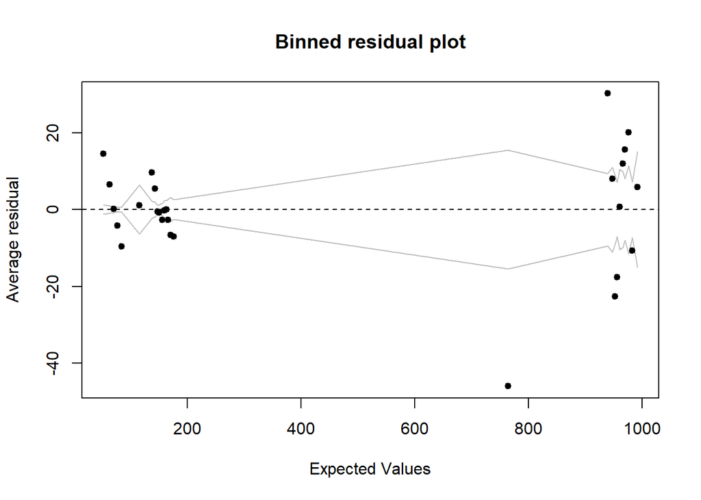

```r
binnedplot(predict(m2), resid(m2), main="Binned residual plot")
```